# Do NFL players Live Shorter Lives?

Spencer Cook

November 7, 2017

## Background

The health of NFL players is becoming a rising issue in the country. One reason for this is the discovery of CTE, a degenerative brain disease caused by repetitive brain trauma. People are now questioning if the sport is safe.

Some report that average life expectancy for NFL players is much lower than the general population. One Harvard professor said that "professional football players in both the United States and Canada have life expectancies in the mid to late 50’s." [^1]

On the contrary, we also see studies reporting the opposite. The National institute for Occupational Health and Safety reported, "We found the players in our study had a much lower rate of death overall compared to men in the general population. This means that, on average, NFL players (77.5-year life expectancy) are actually living longer than men in the general population (74.7 years)." [^2]

These are very conflicting conclusions. In this project, I am attempting to find out if NFL players die sooner or later than the general male population.

## Examples of Poor Analysis

When dealing with life expectancy, it is easy to misrepresent the data. This first bar plot is taking the median age of death for the players in the dataset and comparing it to United States life expectancy in 2005 for males. The problem with this plot is that it is only accounting for NFL players that have died. There are thousands of players that are alive and surpassing the age they were expected to die. A proper analysis of the data will account for all players. Accounting for just age of death can easily make it look like NFL players don't live as long as the general public.

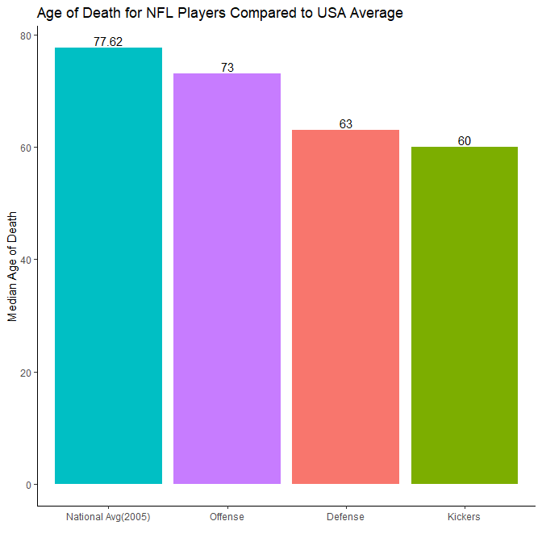

```r
nfl_survival$age_years <- as.numeric(nfl_survival$age_years)
nfl_survival %>%
  filter(status == "dead") %>%
  group_by(type) %>%
  summarise(avg_age = median(age_years)) %>%
  add_row(type = "National Avg(2005)", avg_age = 77.62) %>%
  ggplot() +
  geom_bar(aes(x = reorder(type, -avg_age), avg_age, fill = type), stat = "identity") +
  labs(y = "Median Age of Death", title = "Age of Death for NFL Players Compared to USA Average", x = "") +
  guides(fill = FALSE) +
  geom_text(aes(type, avg_age, label = avg_age), position = position_dodge(), vjust = -.25) +
  theme_classic()
```

This next example of a bad visualization is particularly interesting. For this graph, life expectancy was gathered for each year in the past century. The NFL players dataset contains the birthyear of each player, so their age was subtracted from the life expectancy corresponding to the players birth year. This difference between expected age and actual age was the variable used for the histogram.

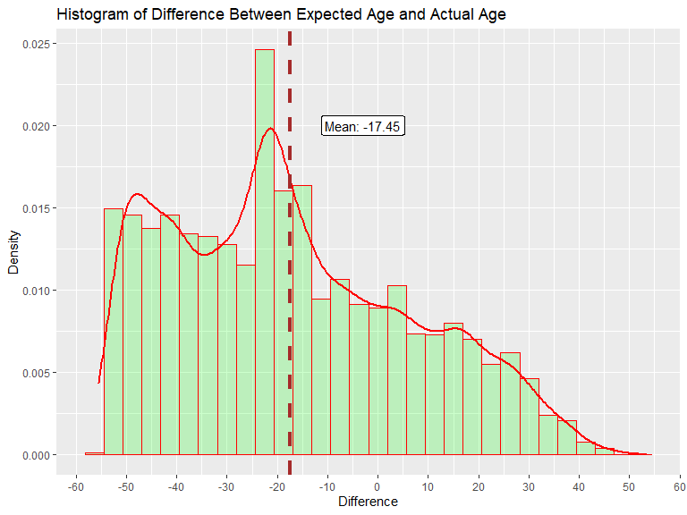

```r
#histogram of difference
ggplot(nfl_life, aes(x = difference)) +
    geom_histogram(aes(y = ..density..), col = "red", fill = "green", alpha = .2) +
    geom_density(color = 2, size = 1) +
    geom_vline(aes(xintercept = mean(difference)), col = "brown", size = 1.5, linetype = "dashed") +
    scale_x_continuous(breaks = seq(-60, 60, 10)) +
    annotate("label", label = "Mean: -17.45", x = -3, y = .02) +
    labs(title = "Histogram of Difference Between Expected Age and Actual Age", y = "Density", x = "Difference") +
    theme_grey()
```

This may seem informative at first, but it still does not properly account for players that are alive. The mean difference was -17.45. Perhaps this is how some conclude that life expectancy for NFL players is in the high 50's, since 77.62 minus 17.45 is about 60. NFL players very well might live less than the general population, but that is not a conclusion that can be made from these visualizations.

## Better Data

For this project I decided that the most appropriate way to describe the data would be with Kaplan-Meier curves. These curves take the population of the data you are working with and report the probability for a subject to survive to a specific age. This works better because it accounts for all players, dead and alive.

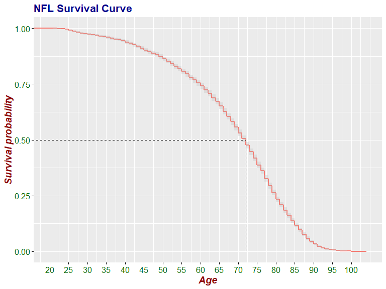

```r
nfl_surv <- survfit(Surv(age_years, dead)~1, data = nfl_survival)
ggnfl <- ggsurvplot(nfl_surv, surv.median.line = "hv", break.x.by = 5, legend = "none",
           title = "NFL Survival Curve", xlab = "Age",
           xlim = c(20,104), conf.int = TRUE, ggtheme = theme_grey())

ggnfl$plot <- ggnfl$plot + labs(
  title = "NFL Survival Curve")

ggnfl <- ggpar(
  ggnfl,
  font.title = c(16, "bold", "darkblue"),
  font.x = c(14, "bold.italic", "darkred"),
  font.y = c(14, "bold.italic", "darkred"),
  font.xtickslab = c(12, "plain", "darkgreen"),
  font.ytickslab = c(12, "plain", "darkgreen")
)

ggnfl
```

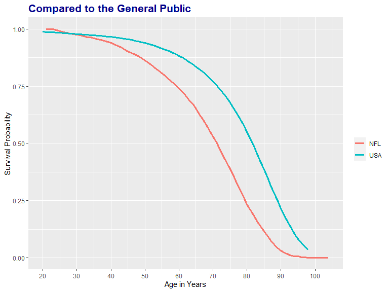

```r
# convert to ggplot format
res <- fortify(nfl_surv)

ggplot(res, aes(time, surv, color = "NFL")) +
    geom_line(size = 1.2) +
    geom_line(data = life07, aes(age_years, percent_survived, color = "USA"), size = 1.2) +
    labs(y = "Survival Probability", x = "Age in Years", title = "Compared to the General Public", colour = "") +
    theme(plot.title = element_text(hjust = .5)) +
    scale_x_continuous(breaks = seq(20,100,10)) +
    theme_grey() +
    theme(plot.title = element_text(color = "darkblue", face = "bold", size = 16))
```

## Who's bringing it down?

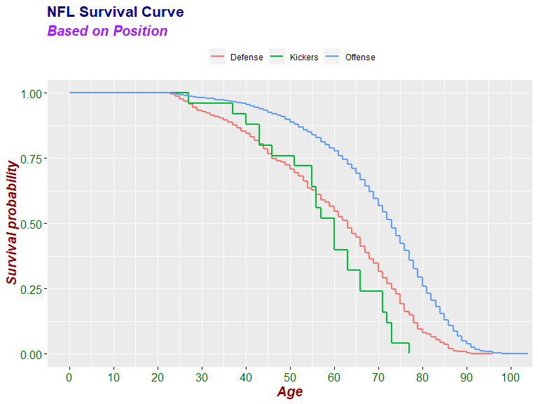

```r
# Survival curve for position type
type_surv <- survfit(Surv(age_years, dead)~type, data = nfl_survival)
ggpos <- ggsurvplot(type_surv, break.x.by = 10, legend.title = "",
           legend.labs = c("Defense", "Kickers", "Offense"), xlab = "Age",
           ggtheme = theme_grey())

ggpos$plot <- ggpos$plot + labs(
  title = "NFL Survival Curve",
  subtitle = "Based on Position"
)

ggpos <- ggpar(
  ggpos,
  font.title = c(16, "bold", "darkblue"),
  font.subtitle = c(15, "bold.italic", "purple"),
  font.xtickslab = c(12, "plain", "darkgreen"),
  font.ytickslab = c(12, "plain", "darkgreen"),
  font.x = c(14, "bold.italic", "darkred"),
  font.y = c(14, "bold.italic", "darkred")
)

ggpos
```

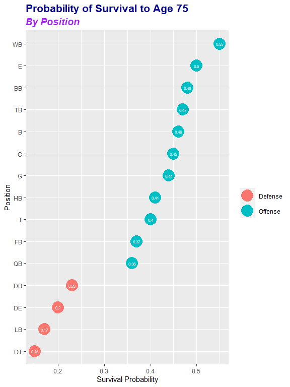

```r
# grouped
survprim <- survfit(Surv(age_years, dead)~primary, data = nfl_survival)

survprim <- fortify(survprim)

survprimorder <- survprim %>%
  filter(time == 75) %>%
  mutate(surv = round(surv, digits = 2)) %>%
  mutate(strata = str_trim(str_to_lower(strata)),
    type = case_when(
      str_detect(strata, paste(defense, collapse = "|")) ~ "Defense",
      str_detect(strata, paste(offense, collapse = "|")) ~ "Offense",
      str_detect(strata, paste(kickers, collapse = "|")) ~ "Kickers"
    ), strata = str_to_upper(strata))


survprimorder$strata <- factor(survprimorder$strata, levels = survprimorder$strata[order(survprimorder$surv)])

survprimorder %>%
ggplot(aes(x = strata, y = surv, label = surv)) +
    geom_point(stat = 'identity', aes(col = type), size = 8) +
    geom_text(color = "white", size = 2) +
    coord_flip() +
    theme_grey() +
    labs(y = "Survival Probability", x = "Position", title = "Probability of Survival to Age 75", subtitle = "By Position", col = "") +
    theme(plot.title = element_text(size = 16, color = 'darkblue', face = 'bold'),
          plot.subtitle = element_text(size = 14, color = 'purple', face = 'bold.italic'))
```

# Is There a Trend in Weight?

The dataset contains information on height and weight, which allows for a BMI calculation. Are there a lot of overweight players in the NFL? If so, are they dying sooner?

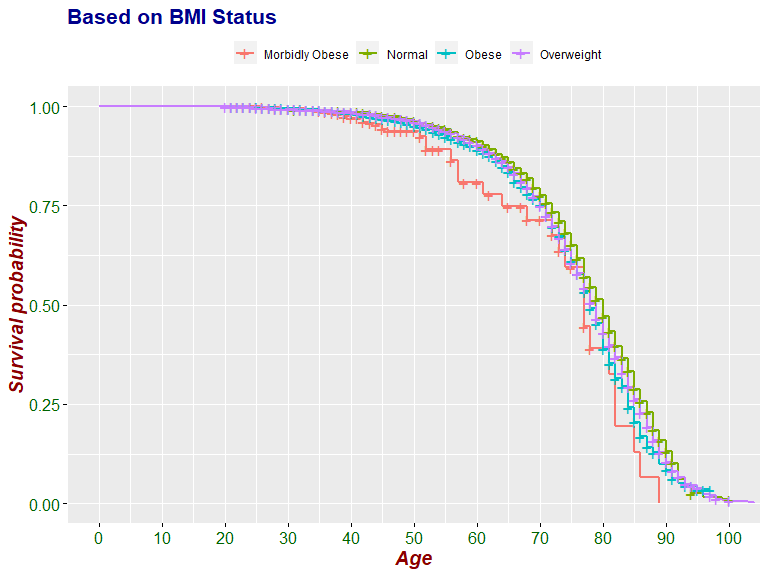

```r
# even heights are in different date format
# need to fix legend order

BMI_surv <- survfit(Surv(age_years, dead)~weight_status, data = BMI)
ggbmi <- ggsurvplot(BMI_surv, break.x.by = 10, legend.title = "",
           legend.labs = c("Morbidly Obese", "Normal", "Obese",
                           "Overweight"),
           xlab = "Age", ggtheme = theme_grey())

ggbmi$plot <- ggbmi$plot + labs(
  title = "Based on BMI Status"
)

ggbmi <- ggpar(
  ggbmi,
  font.title = c(16, "bold", "darkblue"),
  font.x = c(14, "bold.italic", "darkred"),
  font.y = c(14, "bold.italic", "darkred"),
  font.xtickslab = c(12, "plain", "darkgreen"),
  font.ytickslab = c(12, "plain", "darkgreen")
)

ggbmi
```

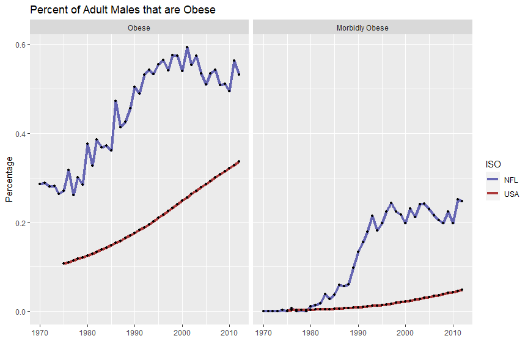

```r
obese <- c(`10` = "Morbidly Obese", `9` = "Obese")

ggplot(data = joined_obese, aes(perc, value)) +
  geom_line(data = joined_obese, aes(perc, value, group = percent, color = ISO), size = 1.5) +
  geom_point(size = 1) +
  labs(x = "", y = "Percentage", title = "Percent of Adult Males that are Obese") +
  scale_color_manual(labels = c("NFL", "USA"), values = c("#6666b3", "#ac3939")) +
  theme(legend.title = element_blank()) +
  facet_wrap(~group, labeller = as_labeller(obese)) +
  theme(plot.title = element_text(hjust = .5, color = 'darkblue', face = 'bold', size = 16)) +
  theme_grey()
```

The USA reportedly has a larger obesity problem than most other countries, so to see that NFL players have a much higher percentage of obese and morbidly obese players is concerning. It is no secret that obesity is a poor indicator for life expectancy.

## Time in the League

Some articles report that NFL players with longer careers have shorter lifespans. One Washington Post writer said, "Various unsurprising studies indicate high early mortality rates among linemen resulting from cardiovascular disease. For all players who play five or more years, life expectancy is less than 60; for linemen it is much less." [^3] This next survival curve groups NFL players by the number of years they played in the league.

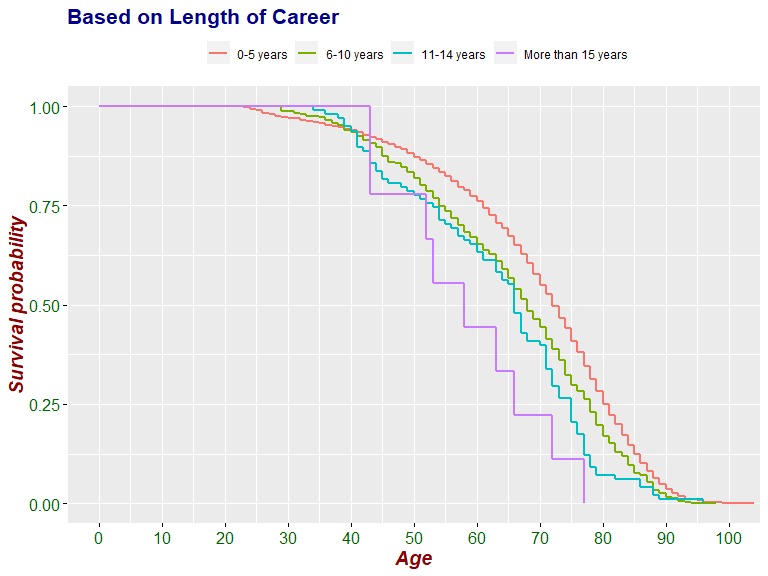

```r
# by years in the league
nfl_survival$start <- as.numeric(nfl_survival$start)
nfl_survival$finish <- as.numeric(nfl_survival$finish)
levels <- c(-Inf, 5, 10, 14, Inf)
labels <- c("0-5", "6-10", "11-14", "More than 15")

years_played <- nfl_survival %>%
  mutate(years_played = finish - start,
         group = cut(years_played, levels, labels = labels))

years_surv <- survfit(Surv(age_years, dead)~group, data = years_played)
ggyear <- ggsurvplot(years_surv, legend.title = "", break.x.by = 10,
                     legend.labs = c("0-5 years", "6-10 years", "11-14 years",
                                     "More than 15 years"),
                     xlab = "Age", ggtheme = theme_grey())

ggyear$plot <- ggyear$plot + labs(
  title = "Based on Length of Career"
)

ggyear <- ggpar(
  ggyear,
  font.title = c(16, "bold", "darkblue"),
  font.x = c(14, "bold.italic", "darkred"),
  font.y = c(14, "bold.italic", "darkred"),
  font.xtickslab = c(12, "plain", "darkgreen"),
  font.ytickslab = c(12, "plain", "darkgreen")
)

ggyear
```

## Time Period

Perhaps the most important thing to consider with this data is that it contains NFL players that were born nearly a century ago. Life expectancy was obviously much lower then. It's necessary to check and make sure that this factor is not skewing our data. This next plot will look at probability of survival based on what time period the players were in the league.

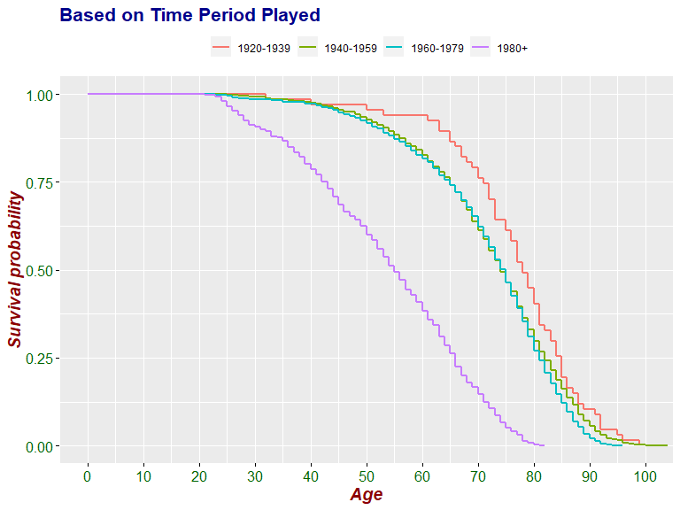

```r
levels <- c(-Inf, 1920, 1940, 1960, Inf)
labels <- c("1920-1939", "1940-1959", "1960-1979", "1980+")

decade <- nfl_survival %>%
  mutate(decade = cut(finish, levels, labels = labels))

decade_surv <- survfit(Surv(age_years, dead)~decade, data = decade)
ggdec <- ggsurvplot(decade_surv, legend.title = "", break.x.by = 10,
                    legend.labs = c("1920-1939", "1940-1959", "1960-1979",
                                    "1980+"), xlab = "Age",
                    ggtheme = theme_grey())

ggdec$plot <- ggdec$plot + labs(
  title = "Based on Time Period Played"
)

ggdec <- ggpar(
  ggdec,
  font.title = c(16, "bold", "darkblue"),
  font.x = c(14, "bold.italic", "darkred"),
  font.y = c(14, "bold.italic", "darkred"),
  font.xtickslab = c(12, "plain", "darkgreen"),
  font.ytickslab = c(12, "plain", "darkgreen")
)

ggdec
```

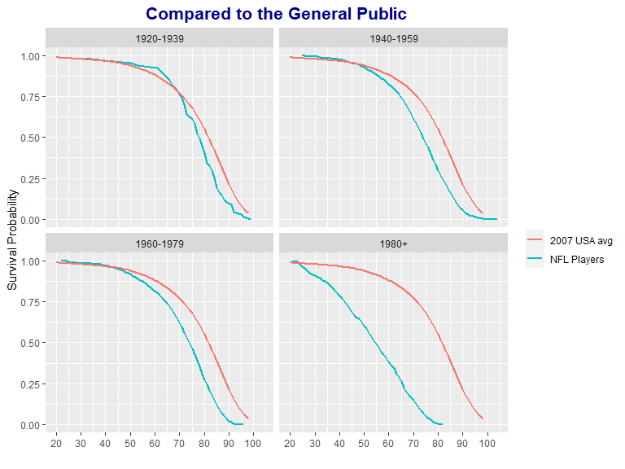

```r
dec <- fortify(decade_surv)

ggplot(dec, aes(time, surv)) +
    geom_line(size = 1, aes(color = "NFL Players")) +
    geom_line(data = life07, aes(age_years, percent_survived, color = "2007 USA avg"), size = 1) +
    labs(y = "Survival Probability", x = "", title = "Compared to the General Public", colour = "") +
    scale_x_continuous(breaks = seq(20,100,10)) +
    facet_wrap(~strata) +
    theme_grey() +
    theme(plot.title = element_text(hjust = .5, color = 'darkblue', face = 'bold', size = 16))
```

## Conclusion

If someone has dedicated their life to football to be able to play in the NFL, the have sacrificed their body for years. That could take a toll on someone, yet these players do enjoy some of the best medical care while they are playing. Yet, players with short careers have gone through lifelong preparation to lose this care quickly.

### References

[^1]: https://www.forbes.com/sites/realspin/2013/08/18/why-everything-you-hear-about-the-deadly-game-of-football-is-false/#4a0091743778
[^2]: https://operations.nfl.com/the-players/development-pipeline/college-advisory-committee/nfl-player-fact-vs-fiction/
[^3]: https://www.washingtonpost.com/opinions/george-f-will-footballs-problem-with-danger-on-the-field-isnt-going-away/2012/08/03/ff71ec48-dcd0-11e1-8e43-4a3c4375504a_story.html?